# Quiz 1 Assignment 2

Wilmer Uruchi Ticona

11/2/2018

Load Libraries:

```r
library(RcmdrMisc)
library(dplyr)
```

```r
library(ggplot2)
library("lmtest")
library(FactoMineR)
```

First, I generate some populations:

```r
Norm_v1 = rnorm(200, mean = 0, sd = 1)
Norm_v2 = rnorm(200, mean = 10, sd = 1)
Norm_v3 = rnorm(200, mean = 3, sd = 1)
```

Then, lets make a quick data transformation:

```r
Norm_v1n=data.frame(x1=Norm_v1, x2="v1")
Norm_v2n=data.frame(x1=Norm_v2, x2="v2")
Norm_v3n=data.frame(x1=Norm_v3, x2="v3")
```

Then, lets merge the data:

```r
data=mergeRows(Norm_v1n, Norm_v2n, common.only=FALSE)
data=mergeRows(as.data.frame(data), Norm_v3n, common.only=FALSE)
```

I proceed to apply the ANOVA test. Lets begin by checking the necessary asumptions:

- *The observations are independent within and across groups*: Given the fact that we used an r function to generate a random normal distribution, we can assume independence.
- *The data within each group are nearly normal*: Taken from the previous point. However, let’s visualize the distribution of the samples:

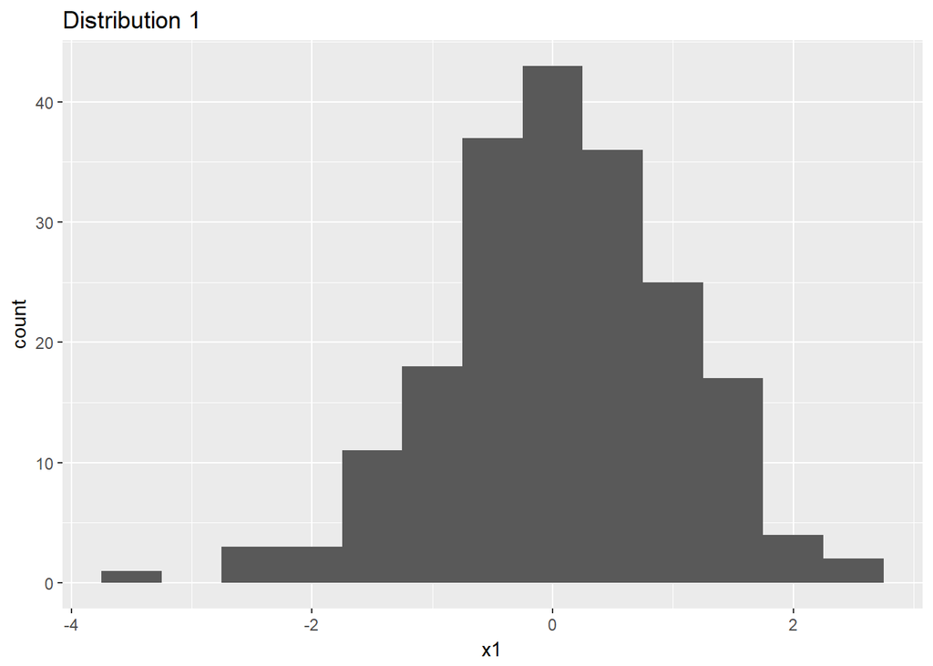

```r
ggplot(data = Norm_v1n, aes(x = x1)) +
  geom_histogram(binwidth = 0.5) +
  ggtitle("Distribution 1")
```

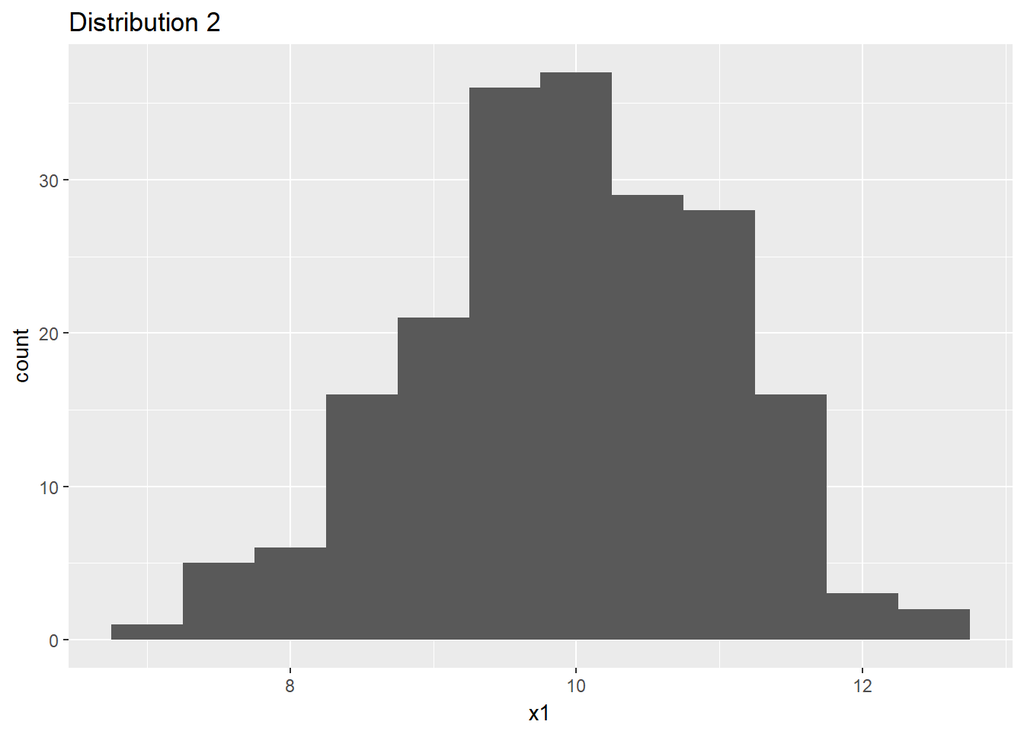

```r
ggplot(data = Norm_v2n, aes(x = x1)) +
  geom_histogram(binwidth = 0.5) +
  ggtitle("Distribution 2")
```

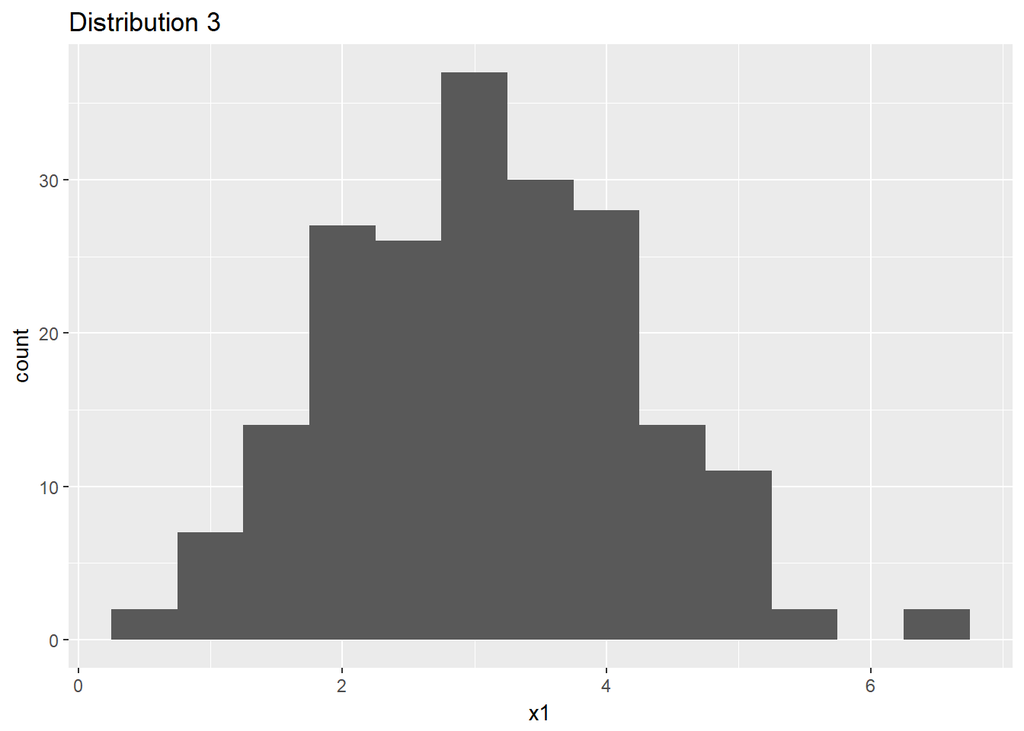

```r
ggplot(data = Norm_v3n, aes(x = x1)) +
  geom_histogram(binwidth = 0.5) +
  ggtitle("Distribution 3")
```

- *The variability across groups is about equal*: Using a standard deviation of 1 in the function we can assume that the variability across the groups is nearly equal.

Perform the ANOVA test:

```r
AnovaModel.1 <- aov(x1 ~ x2, data=data)
summary(AnovaModel.1)
```

```
##              Df Sum Sq Mean Sq F value Pr(>F)
## x2            2  10281    5140    4617 <2e-16 ***
## Residuals   597    665       1
## ---
## Signif. codes:  0 '***' 0.001 '**' 0.01 '*' 0.05 '.' 0.1 ' ' 1
```

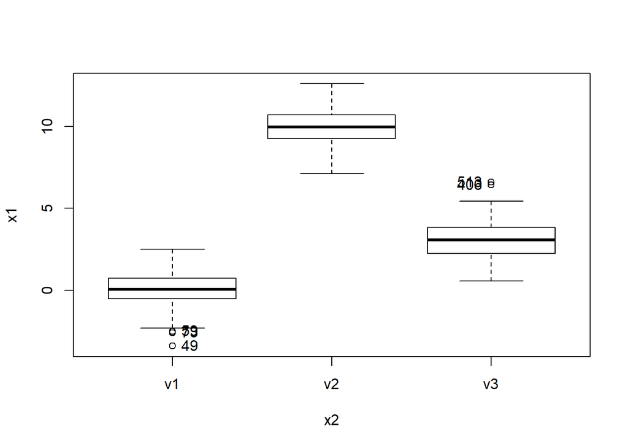

```
## [1] "49"  "59"  "73"  "406" "513"
```

```r
Boxplot(x1~x2, data=data, id.method="y")
```

The p-value is less than the alpha = 0.05 so we reject the null hypothesis that says that the mean outcome is the same across all samples.

Testing assumptions:

*Shapiro Test:* The populations from which the samples are selected must be normal:

```r
shapiro.test(residuals(AnovaModel.1))
```

```
##
##  Shapiro-Wilk normality test
##
## data:  residuals(AnovaModel.1)
## W = 0.99888, p-value = 0.9759
```

Given p-value > 0.05, the alternative hypothesis (samples not normally distruted) is rejected.

*Durbin Watson:* The observations within each sample must be independent.

```r
dwtest(AnovaModel.1, alternative ="two.sided")
```

```
##
##  Durbin-Watson test
##
## data:  AnovaModel.1
## DW = 2.0851, p-value = 0.3357
## alternative hypothesis: true autocorrelation is not 0
```

Given p-value > 0.05, the alternative hypothesis (observations within each sample are not independent) is rejected.

*Breusch Pagan Test:* The populations from which the samples are selected must be equal variances (homogeneity of variance).

```r
lmtest::bptest(AnovaModel.1)
```

```
##
##  studentized Breusch-Pagan test
##
## data:  AnovaModel.1
## BP = 2.9663, df = 2, p-value = 0.2269
```

Given p-value > 0.05, the alternative hypothesis (variances are not equal) is rejected.

On the dataset contained on FactoMiner package named decathlon, we want to analyze if both competitions achieve different results in the different disciplines analyzed.

```r
data(decathlon, package="FactoMineR")
decathlon
```

[output not shown]

[output cut: 29 more lines]

```
## Smith             4.20    61.52 272.74   14   8023    OlympicG
## Averyanov         4.80    54.51 271.02   15   8021    OlympicG
## Ojaniemi          4.60    59.26 275.71   16   8006    OlympicG
## Smirnov           4.70    60.88 263.31   17   7993    OlympicG
## Qi                4.50    60.79 272.63   18   7934    OlympicG
## Drews             5.00    51.53 274.21   19   7926    OlympicG
## Parkhomenko       4.80    65.82 277.94   20   7918    OlympicG
## Terek             5.30    50.62 290.36   21   7893    OlympicG
## Gomez             4.40    60.71 269.70   22   7865    OlympicG
## Turi              4.80    59.34 290.01   23   7708    OlympicG
## Lorenzo           4.50    58.36 263.08   24   7592    OlympicG
## Karlivans         4.50    52.92 278.67   25   7583    OlympicG
## Korkizoglou       4.70    53.05 317.00   26   7573    OlympicG
## Uldal             4.50    60.00 281.70   27   7495    OlympicG
## Casarsa           4.40    58.62 296.12   28   7404    OlympicG
```

Lets start by building the necessary dataSets:

```r
colnames(decathlon) <- c("com100", "LongJump","ShotPut","HighJump","com400","com110Hurdle","Discus","PoleVault","Javeline","com1500","RankFinal","Points","Competition")

deca100m <- decathlon %>%
            select(com100,Competition)
decaLongJump <- decathlon %>%
            select(LongJump,Competition)
decaShotPut <- decathlon %>%
            select(ShotPut,Competition)
decaHighJump <- decathlon %>%
            select(HighJump,Competition)
decaCom400 <- decathlon %>%
            select(com400,Competition)
deca100Hurdle <- decathlon %>%
            select(com110Hurdle,Competition)
decaDiscus <- decathlon %>%
            select(Discus,Competition)
decaPoleVault <- decathlon %>%
            select(PoleVault,Competition)
decaJaveline <- decathlon %>%
            select(Javeline,Competition)
deca1500 <- decathlon %>%
            select(com1500,Competition)
```

Lets apply ANOVA to some of these data sets:

```r
## Com 100
AnovaModel.1.1 <- aov(com100 ~ Competition, data=deca100m)
summary(AnovaModel.1.1)
```

```
##             Df Sum Sq Mean Sq F value  Pr(>F)
## Competition  1 0.5986  0.5986   10.77 0.00218 **
## Residuals   39 2.1686  0.0556
## ---
## Signif. codes:  0 '***' 0.001 '**' 0.01 '*' 0.05 '.' 0.1 ' ' 1
```

```r
AnovaModel.1.2 <- aov(LongJump ~ Competition, data=decaLongJump)
summary(AnovaModel.1.2)
```

```
##             Df Sum Sq Mean Sq F value Pr(>F)
## Competition  1  0.003 0.00288   0.028  0.868
## Residuals   39  4.002 0.10260
```

```r
AnovaModel.1.3 <- aov(ShotPut ~ Competition, data=decaShotPut)
summary(AnovaModel.1.3)
```

```
##             Df Sum Sq Mean Sq F value Pr(>F)
## Competition  1  1.932  1.9324   2.984  0.092 .
## Residuals   39 25.255  0.6476
## ---
## Signif. codes:  0 '***' 0.001 '**' 0.01 '*' 0.05 '.' 0.1 ' ' 1
```

```r
AnovaModel.1.4 <- aov(HighJump ~ Competition, data=decaHighJump)
summary(AnovaModel.1.4)
```

```
##             Df Sum Sq  Mean Sq F value Pr(>F)
## Competition  1 0.0000 0.000014   0.002  0.967
## Residuals   39 0.3165 0.008115
```

```r
AnovaModel.1.5 <- aov(com400 ~ Competition, data=decaCom400)
summary(AnovaModel.1.5)
```

```
##             Df Sum Sq Mean Sq F value Pr(>F)
## Competition  1   0.00  0.0036   0.003   0.96
## Residuals   39  53.21  1.3645
```

```r
AnovaModel.1.6 <- aov(com110Hurdle ~ Competition, data=deca100Hurdle)
summary(AnovaModel.1.6)
```

```
##             Df Sum Sq Mean Sq F value Pr(>F)
## Competition  1  0.241  0.2414   1.087  0.304
## Residuals   39  8.662  0.2221
```

```r
AnovaModel.1.7 <- aov(Discus ~ Competition, data=decaDiscus)
summary(AnovaModel.1.7)
```

```
##             Df Sum Sq Mean Sq F value Pr(>F)
## Competition  1    0.2   0.222   0.019  0.891
## Residuals   39  456.2  11.697
```

```r
AnovaModel.1.8 <- aov(PoleVault ~ Competition, data=decaPoleVault)
summary(AnovaModel.1.8)
```

```
##             Df Sum Sq Mean Sq F value Pr(>F)
## Competition  1 0.0811 0.08105    1.05  0.312
## Residuals   39 3.0103 0.07719
```

```r
AnovaModel.1.9 <- aov(Javeline ~ Competition, data=decaJaveline)
summary(AnovaModel.1.9)
```

```
##             Df Sum Sq Mean Sq F value Pr(>F)
## Competition  1   35.3   35.31   1.536  0.223
## Residuals   39  896.6   22.99
```

```r
AnovaModel.1.10 <- aov(com1500 ~ Competition, data=deca1500)
summary(AnovaModel.1.10)
```

```
##             Df Sum Sq Mean Sq F value Pr(>F)
## Competition  1    192   191.9   1.423   0.24
## Residuals   39   5259   134.8
```

Finally, lets test some assumptions:

```r
shapiro.test(residuals(AnovaModel.1.1))
```

```
##
##  Shapiro-Wilk normality test
##
## data:  residuals(AnovaModel.1.1)
## W = 0.97525, p-value = 0.5023
```

```r
shapiro.test(residuals(AnovaModel.1.2))
```

```
##
##  Shapiro-Wilk normality test
##
## data:  residuals(AnovaModel.1.2)
## W = 0.98831, p-value = 0.9437
```

```r
shapiro.test(residuals(AnovaModel.1.3))
```

```
##
##  Shapiro-Wilk normality test
##
## data:  residuals(AnovaModel.1.3)
## W = 0.9726, p-value = 0.4175
```

```r
shapiro.test(residuals(AnovaModel.1.4))
```

```
##
##  Shapiro-Wilk normality test
##
## data:  residuals(AnovaModel.1.4)
## W = 0.93672, p-value = 0.02428
```

```r
shapiro.test(residuals(AnovaModel.1.5))
```

```
##
##  Shapiro-Wilk normality test
##
## data:  residuals(AnovaModel.1.5)
## W = 0.95672, p-value = 0.1206
```

```r
shapiro.test(residuals(AnovaModel.1.6))
```

```
##
##  Shapiro-Wilk normality test
##
## data:  residuals(AnovaModel.1.6)
## W = 0.93428, p-value = 0.02009
```

```r
shapiro.test(residuals(AnovaModel.1.7))
```

```
##
##  Shapiro-Wilk normality test
##
## data:  residuals(AnovaModel.1.7)
## W = 0.97003, p-value = 0.3455
```

```r
shapiro.test(residuals(AnovaModel.1.8))
```

```
##
##  Shapiro-Wilk normality test
##
## data:  residuals(AnovaModel.1.8)
## W = 0.97879, p-value = 0.6299
```

```r
shapiro.test(residuals(AnovaModel.1.9))
```

```
##
##  Shapiro-Wilk normality test
##
## data:  residuals(AnovaModel.1.9)
## W = 0.97474, p-value = 0.4852
```

```r
shapiro.test(residuals(AnovaModel.1.10))
```

```
##
##  Shapiro-Wilk normality test
##
## data:  residuals(AnovaModel.1.10)
## W = 0.93826, p-value = 0.02741
```

```r
dwtest(AnovaModel.1.1, alternative ="two.sided")
```

```
##
##  Durbin-Watson test
##
## data:  AnovaModel.1.1
## DW = 1.2595, p-value = 0.008235
## alternative hypothesis: true autocorrelation is not 0
```

```r
dwtest(AnovaModel.1.2, alternative ="two.sided")
```

```
##
##  Durbin-Watson test
##
## data:  AnovaModel.1.2
## DW = 1.3741, p-value = 0.02544
## alternative hypothesis: true autocorrelation is not 0
```

```r
dwtest(AnovaModel.1.3, alternative ="two.sided")
```

```
##
##  Durbin-Watson test
##
## data:  AnovaModel.1.3
## DW = 1.4425, p-value = 0.04577
## alternative hypothesis: true autocorrelation is not 0
```

```r
dwtest(AnovaModel.1.4, alternative ="two.sided")
```

```
##
##  Durbin-Watson test
##
## data:  AnovaModel.1.4
## DW = 2.1012, p-value = 0.8665
## alternative hypothesis: true autocorrelation is not 0
```

```r
dwtest(AnovaModel.1.5, alternative ="two.sided")
```

```
##
##  Durbin-Watson test
##
## data:  AnovaModel.1.5
## DW = 1.3938, p-value = 0.03032
## alternative hypothesis: true autocorrelation is not 0
```

```r
dwtest(AnovaModel.1.6, alternative ="two.sided")
```

```
##
##  Durbin-Watson test
##
## data:  AnovaModel.1.6
## DW = 1.5083, p-value = 0.07622
## alternative hypothesis: true autocorrelation is not 0
```

```r
dwtest(AnovaModel.1.7, alternative ="two.sided")
```

```
##
##  Durbin-Watson test
##
## data:  AnovaModel.1.7
## DW = 1.342, p-value = 0.01889
## alternative hypothesis: true autocorrelation is not 0
```

```r
dwtest(AnovaModel.1.8, alternative ="two.sided")
```

```
##
##  Durbin-Watson test
##
## data:  AnovaModel.1.8
## DW = 2.0017, p-value = 0.8782
## alternative hypothesis: true autocorrelation is not 0
```

```r
dwtest(AnovaModel.1.9, alternative ="two.sided")
```

```
##
##  Durbin-Watson test
##
## data:  AnovaModel.1.9
## DW = 2.1099, p-value = 0.8442
## alternative hypothesis: true autocorrelation is not 0
```

```r
dwtest(AnovaModel.1.10, alternative ="two.sided")
```

```
##
##  Durbin-Watson test
##
## data:  AnovaModel.1.10
## DW = 1.7303, p-value = 0.3011
## alternative hypothesis: true autocorrelation is not 0
```

```r
lmtest::bptest(AnovaModel.1.1)
```

```
##
##  studentized Breusch-Pagan test
##
## data:  AnovaModel.1.1
## BP = 0.040711, df = 1, p-value = 0.8401
```

```r
lmtest::bptest(AnovaModel.1.2)
```

```
##
##  studentized Breusch-Pagan test
##
## data:  AnovaModel.1.2
## BP = 1.2574, df = 1, p-value = 0.2621
```

```r
lmtest::bptest(AnovaModel.1.3)
```

```
##
##  studentized Breusch-Pagan test
##
## data:  AnovaModel.1.3
## BP = 1.2645, df = 1, p-value = 0.2608
```

```r
lmtest::bptest(AnovaModel.1.4)
```

```
##
##  studentized Breusch-Pagan test
##
## data:  AnovaModel.1.4
## BP = 0.0097937, df = 1, p-value = 0.9212
```

```r
lmtest::bptest(AnovaModel.1.5)
```

```
##
##  studentized Breusch-Pagan test
##
## data:  AnovaModel.1.5
## BP = 1.0517, df = 1, p-value = 0.3051
```

```r
lmtest::bptest(AnovaModel.1.6)
```

```
##
##  studentized Breusch-Pagan test
##
## data:  AnovaModel.1.6
## BP = 1.1326, df = 1, p-value = 0.2872
```

```r
lmtest::bptest(AnovaModel.1.7)
```

```
##
##  studentized Breusch-Pagan test
##
## data:  AnovaModel.1.7
## BP = 0.21492, df = 1, p-value = 0.6429
```

```r
lmtest::bptest(AnovaModel.1.8)
```

```
##
##  studentized Breusch-Pagan test
##
## data:  AnovaModel.1.8
## BP = 0.50795, df = 1, p-value = 0.476
```

```r
lmtest::bptest(AnovaModel.1.9)
```

```
##
##  studentized Breusch-Pagan test
##
## data:  AnovaModel.1.9
## BP = 0.41184, df = 1, p-value = 0.521
```

```r
lmtest::bptest(AnovaModel.1.10)
```

```
##
##  studentized Breusch-Pagan test
##
## data:  AnovaModel.1.10
## BP = 0.030018, df = 1, p-value = 0.8624
```